# Disconnect Switch Descriptive Analysis

(5/15) The first thing I want to do with these data is perform one of the same analyses I performed with the ‘Easy Feed Switch’ data, which is to see whether switch costs and reward sensitivity interact to predict block times. The prediction here is tricky because if I measure reward sensitivity as the difference slope predicting switch rates when difference > 0, you could imagine that a high flat line at ceiling might be most ideal (such that difference slope would be near 0). But maybe not. Maybe the first thing to do here is descriptively analyze what the difference-switch relationship looks like in these data.

```r
library(tidyverse)
library(lme4)
library(data.table)
```

```r
current_data <- fread('../../data/disconnect_switch.csv')
cued_data <- fread('../../data/cued_data.csv')
```

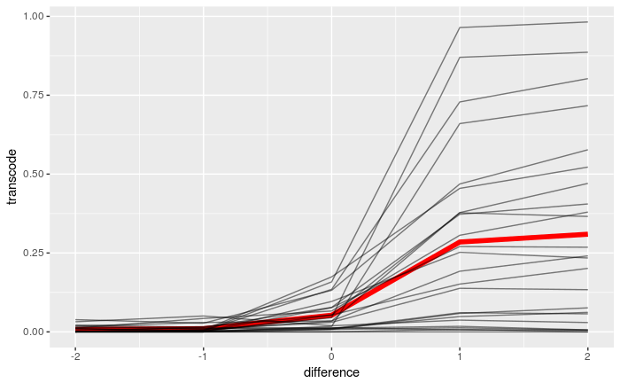

```r
subject_means <- current_data %>%
  group_by(subject, difference) %>%
  summarize(transcode = mean(transcode))

subject_means %>%
  group_by(difference) %>%
  summarize(transcode = mean(transcode)) %>%
  ggplot(aes(x = difference, y = transcode, group = 1)) + geom_line(size = 2, color = 'red') + geom_line(data = subject_means, aes(x = difference, y = transcode, group = subject), alpha = .5)
```

Okay so this is actually super interesting, that’s a real nice distribution. (Red is overall means). One thing that’s noticable here is that the range on the difference is -2:2 instead of -3:3 (like in the easy feed version). After some investigating, points in the easy feed version were actually bounded at min:0, while here the points were bounded at min:1. Kind of frustrating that that’s not consistent across these experiments. Looking at this graph, I think it makes much more sense to consider subject slopes on >=0 on the difference.. it really looks like most of the action is between 0 and 1, but some subjects show some slope between 1 and 2. Those between-difference level slopes are going to get lost if i just consider one slope between 0 and 2. Would it make sense to treat difference as a factor.. ? It’s certainly not a nominal variable, but if it was a factor then running a model might result in two coefficients for the two levels of the difference?

Maybe the next step should be to break down the graph above by switch rates.. and maybe even block times..

```r
current_data <- current_data %>%
  mutate(subject = as.numeric(subject)) %>%
  inner_join(cued_data[,c('subject','switch_cost')])
## from here summarize block times at a subject level for doing a mean split
block_data <- current_data %>%
  group_by(subject, block) %>%
  summarize(blocktime = mean(blocktime)) %>%
  group_by(subject) %>%
  summarize(blocktime_avg = mean(blocktime))
current_data <- current_data %>%
  inner_join(block_data)
## save out this updated dataset
write.csv(current_data, '../../data/disconnect_switch_complete.csv')
```

Looking at the distributions for switch costs and block times first:

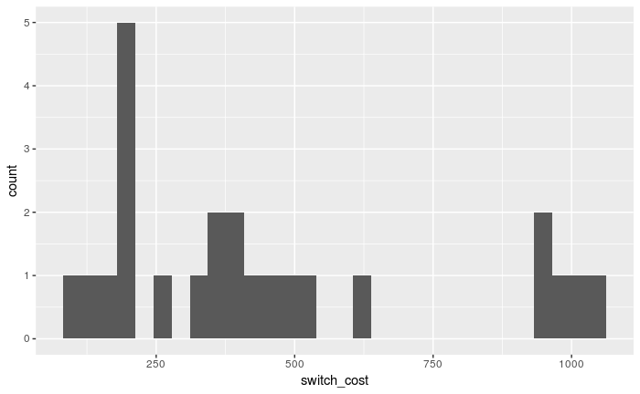

```r
current_data %>%
  group_by(subject) %>%
  summarize(switch_cost = mean(switch_cost)) %>%
  ggplot(aes(x = switch_cost)) + geom_histogram()
```

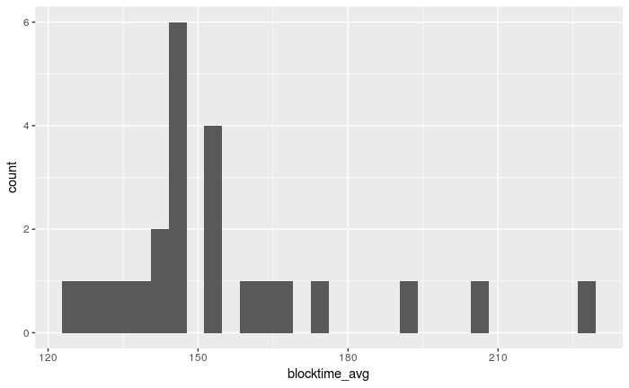

```r
current_data %>%
  group_by(subject) %>%
  summarize(blocktime_avg = mean(blocktime_avg)) %>%
  ggplot(aes(x = blocktime_avg)) + geom_histogram()
```

I’ll use a median split on these variables to visualize the data.

Redundant way to look at both block times and switch costs in two different plots:

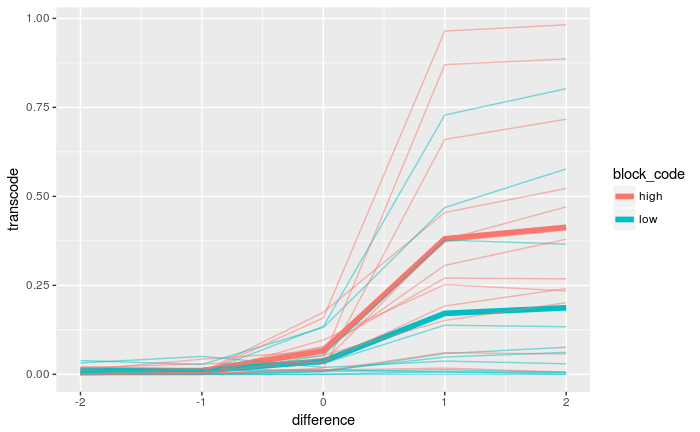

```r
current_data <- current_data %>%
  mutate(blocktime_grand_median = median(blocktime_avg),
         switch_cost_grand_median = median(switch_cost)) %>%
  mutate(switch_code = ifelse(switch_cost >= switch_cost_grand_median, 'high','low'),
         block_code = ifelse(blocktime_avg >= blocktime_grand_median, 'high','low'))
subject_means <- current_data %>%
  group_by(subject, difference, block_code) %>%
  summarize(transcode = mean(transcode))

subject_means %>%
  group_by(difference, block_code) %>%
  summarize(transcode = mean(transcode)) %>%
  ggplot(aes(x = difference, y = transcode, group = block_code)) + geom_line(aes(color = block_code), size = 2) + geom_line(data = subject_means, aes(x = difference, y = transcode, group = subject, color = block_code), alpha = .5)
```

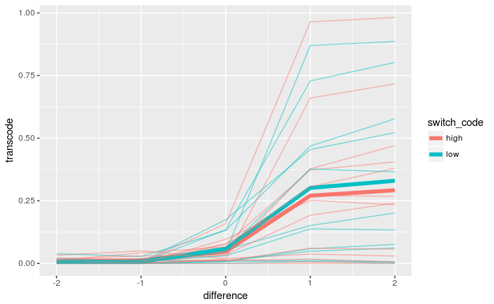

```r
subject_means <- current_data %>%
  group_by(subject, difference, switch_code) %>%
  summarize(transcode = mean(transcode))

subject_means %>%
  group_by(difference, switch_code) %>%
  summarize(transcode = mean(transcode)) %>%
  ggplot(aes(x = difference, y = transcode, group = switch_code)) + geom_line(aes(color = switch_code), size = 2) + geom_line(data = subject_means, aes(x = difference, y = transcode, group = subject, color = switch_code), alpha = .5)
```

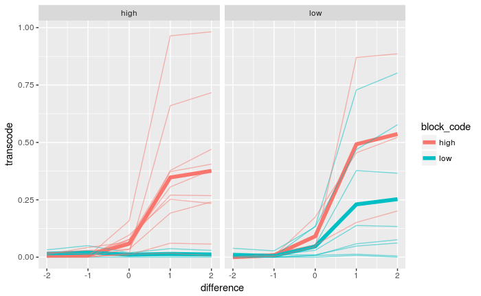

```r
subject_means <- current_data %>%
  group_by(subject, difference, block_code, switch_code) %>%
  summarize(transcode = mean(transcode))

subject_means %>%
  group_by(difference, block_code, switch_code) %>%
  summarize(transcode = mean(transcode)) %>%
  ggplot(aes(x = difference, y = transcode, group = block_code)) + geom_line(aes(color = block_code), size = 2) + geom_line(data = subject_means, aes(x = difference, y = transcode, group = subject, color = block_code), alpha = .5) + facet_wrap(~switch_code)
```

Very interesting, low switch cost subjects tend to have fast block times regardless of their switching strategy, whereas high switch cost subjects appear to have fast block times *only* when adopting a pattern of repeating pretty much regardless of changes in the reward environment.